# Endozoicomonas_species_dynamics_mSystems

Kshitij

2021-1-20

## Input data

refer to data folder for files

```r
otu <- read.table("data/zotu_abundance_table.txt",
                  row.names = 1,
                  header = T,
                  sep = "\t")
head(otu[1:5,1:5])
```

```
##          OB1_4 OB2_4 OB3_4 OB4_4 OB5_4
## zOTU_176     0     0     0     0     0
## zOTU_349     0     0     0     0     0
## zOTU_153     0     0     0     0     0
## zOTU_512     0     0     0     0     0
## zOTU_348     0     0     0     0     0
```

```r
otu <- sqrt(otu)

tax <- read.table("data/zotu_taxtable.txt",
                  row.names = 1,
                  header = T,
                  sep = "\t")
head(tax[1:5,1:5])
```

```
##            Domain         Phylum               Class             Order
## zOTU_176 Bacteria Proteobacteria Gammaproteobacteria Oceanospirillales
## zOTU_349 Bacteria Proteobacteria Gammaproteobacteria Oceanospirillales
## zOTU_153 Bacteria     Chlamydiae          Chlamydiae      Chlamydiales
## zOTU_512 Bacteria Proteobacteria Gammaproteobacteria   Xanthomonadales
## zOTU_348 Bacteria    Tenericutes          Mollicutes Entomoplasmatales
##                                  Family
## zOTU_176                    Hahellaceae
## zOTU_349                    Hahellaceae
## zOTU_153                   Simkaniaceae
## zOTU_512               Xanthomonadaceae
## zOTU_348 Entomoplasmatales_unclassified
```

```r
OTU <- otu_table(otu, taxa_are_rows = TRUE)
head(OTU[1:5,1:5])
```

```
## OTU Table:          [5 taxa and 5 samples]
##                      taxa are rows
##          OB1_4 OB2_4 OB3_4 OB4_4 OB5_4
## zOTU_176     0     0     0     0     0
## zOTU_349     0     0     0     0     0
## zOTU_153     0     0     0     0     0
## zOTU_512     0     0     0     0     0
## zOTU_348     0     0     0     0     0
```

```r
tax <- as.matrix(tax)
TAX <- tax_table(tax)
head(TAX[1:5,1:5])
```

```
## Taxonomy Table:     [5 taxa by 5 taxonomic ranks]:
##          Domain     Phylum           Class                 Order
## zOTU_176 "Bacteria" "Proteobacteria" "Gammaproteobacteria" "Oceanospirillales"
## zOTU_349 "Bacteria" "Proteobacteria" "Gammaproteobacteria" "Oceanospirillales"
## zOTU_153 "Bacteria" "Chlamydiae"     "Chlamydiae"          "Chlamydiales"
## zOTU_512 "Bacteria" "Proteobacteria" "Gammaproteobacteria" "Xanthomonadales"
## zOTU_348 "Bacteria" "Tenericutes"    "Mollicutes"          "Entomoplasmatales"
##          Family
## zOTU_176 "Hahellaceae"
## zOTU_349 "Hahellaceae"
## zOTU_153 "Simkaniaceae"
## zOTU_512 "Xanthomonadaceae"
## zOTU_348 "Entomoplasmatales_unclassified"
```

```r
meta <- read.table("data/zotu_meta.txt",
                   header = T,
                   row.names = 1,
                   sep = "\t")

META <- as.data.frame(meta)
sample_meta <- sample_data(META)
```

### Create a phyloseq object

```r
physeq <- phyloseq(OTU,TAX,sample_meta)
physeq
```

```
## phyloseq-class experiment-level object
## otu_table()   OTU Table:         [ 2064 taxa and 122 samples ]
## sample_data() Sample Data:       [ 122 samples by 7 sample variables ]
## tax_table()   Taxonomy Table:    [ 2064 taxa by 7 taxonomic ranks ]
```

## Filter phyloseq object

Remove *Eukaryota*,unknown, Chloroplast, Mitochondria, and Unclassified  
Bacteria domain, this is to keep zOTUs/ASVs with have are classified at least  
at the phylum level. **Note** if you have already filtered your ASV table for *Eukaryota*, Chloroplast, and Mitochondria you can skip the specific steps.

```r
filtered_physeq <- subset_taxa(physeq,
                               Domain != "Eukaryota")
filtered_physeq
```

```
## phyloseq-class experiment-level object
## otu_table()   OTU Table:         [ 2024 taxa and 122 samples ]
## sample_data() Sample Data:       [ 122 samples by 7 sample variables ]
## tax_table()   Taxonomy Table:    [ 2024 taxa by 7 taxonomic ranks ]
```

```r
filtered_physeq <- subset_taxa(filtered_physeq,
                               Domain != "unknown")
filtered_physeq
```

```
## phyloseq-class experiment-level object
## otu_table()   OTU Table:         [ 2011 taxa and 122 samples ]
## sample_data() Sample Data:       [ 122 samples by 7 sample variables ]
## tax_table()   Taxonomy Table:    [ 2011 taxa by 7 taxonomic ranks ]
```

```r
filtered_physeq <- subset_taxa(filtered_physeq,
                               Family != "Mitochondria")
filtered_physeq
```

```
## phyloseq-class experiment-level object
## otu_table()   OTU Table:         [ 2008 taxa and 122 samples ]
## sample_data() Sample Data:       [ 122 samples by 7 sample variables ]
## tax_table()   Taxonomy Table:    [ 2008 taxa by 7 taxonomic ranks ]
```

```r
filtered_physeq <- subset_taxa(filtered_physeq,
                               Order != "Chloroplast")
filtered_physeq
```

```
## phyloseq-class experiment-level object
## otu_table()   OTU Table:         [ 2008 taxa and 122 samples ]
## sample_data() Sample Data:       [ 122 samples by 7 sample variables ]
## tax_table()   Taxonomy Table:    [ 2008 taxa by 7 taxonomic ranks ]
```

```r
filtered_physeq <- subset_taxa(filtered_physeq,
                               Phylum != "Bacteria_unclassified")
filtered_physeq
```

```
## phyloseq-class experiment-level object
## otu_table()   OTU Table:         [ 1994 taxa and 122 samples ]
## sample_data() Sample Data:       [ 122 samples by 7 sample variables ]
## tax_table()   Taxonomy Table:    [ 1994 taxa by 7 taxonomic ranks ]
```

#### Subset Healthy corals

To compare samples, we first need to subset and extract only Healthy corals as during our experiment we noticed some coral fragments died after transplantation.

```r
healthy_coral <- subset_samples(filtered_physeq,
                                Health == "Healthy")
healthy_coral
```

```
## phyloseq-class experiment-level object
## otu_table()   OTU Table:         [ 1994 taxa and 100 samples ]
## sample_data() Sample Data:       [ 100 samples by 7 sample variables ]
## tax_table()   Taxonomy Table:    [ 1994 taxa by 7 taxonomic ranks ]
```

## Comparing Microbial Community across samples

#### Control samples

In this project we have two location; Inner Bay and Outer Bay.  
These locations harbor different environmental conditions on which the  
coral reefs thrive.

NMDS plot of microbial community in control samples at Outer and Inner Bay

```r
control <- subset_samples(healthy_coral,
                          Type == "Control")

control_dist <- phyloseq::distance(control,
                                   method = "bray")

control_nmds <- ordinate(control,
                         "NMDS",
                         control_dist)
```

```
## *** Solution reached
```

```r
control_nmds$stress
```

```
## [1] 0.1591582
```

[figure not shown]

```r
c1 <- plot_ordination(control,
                      control_nmds,
                      color="Sampletype",
                      shape="Sampletype",
                      title="All control samples Outer and Inner bay") +
      geom_point(size=3) +
      theme_bw() +
      theme(text = element_text(size=10),
            panel.grid = element_blank())

c1 <- c1 +
      scale_color_manual(values = c("burlywood4","yellowgreen"))

c1 <- c1 + stat_ellipse(type="norm",linetype=2)

c1_grob <- grid.text("Stress:0.159")
```

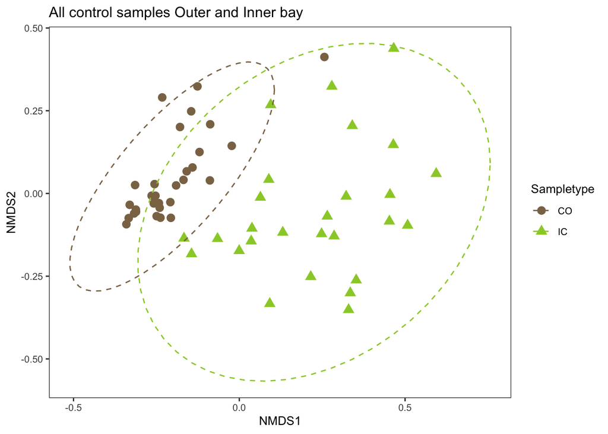

```r
c1 <- c1 +
      annotation_custom(grob = c1_grob,xmin = 0.5, ymin = 0.55)

c1
```

## Phylum level Analysis

```r
data <- read.table("data/All_phylum_only.txt",
                   header = T,
                   row.names = 1,
                   sep = "\t")
data_t <- t(data)

head(data_t[1:5,1:5])
```

```
##       Proteobacteria Chlamydiae Tenericutes Cyanobacteria Bacteroidetes
## OB1_4           7772       4139          23             1            23
## OB2_4          37330       1986          35             6             8
## OB3_4          14230       6379           0             2            16
## OB4_4          29904       7743           4             3            19
## OB5_4          22835       5654           1             2            25
```

```r
rel_abundance <- (data_t/rowSums(data_t))*100

head(rel_abundance[1:5,1:5])
```

```
##       Proteobacteria Chlamydiae Tenericutes Cyanobacteria Bacteroidetes
## OB1_4       64.98328  34.607023 0.192307692   0.008361204    0.19230769
## OB2_4       94.75100   5.040865 0.088836997   0.015229199    0.02030560
## OB3_4       68.97387  30.919490 0.000000000   0.009694150    0.07755320
## OB4_4       79.37570  20.552636 0.010617402   0.007963051    0.05043266
## OB5_4       80.02173  19.813569 0.003504345   0.007008691    0.08760863
```

```r
rel_abundance <- t(rel_abundance)

df_cob_april <- melt(t(rel_abundance[,1:5]))
df_cib_april <- melt(t(rel_abundance[,6:10]))

df_cob_may <- melt(t(rel_abundance[,11:15]))
df_i2o_may <- melt(t(rel_abundance[,16:20]))
df_cib_may <- melt(t(rel_abundance[,21:25]))
df_o2i_may <- melt(t(rel_abundance[,26:30]))

df_cob_june <- melt(t(rel_abundance[,31:35]))
df_i2o_june <- melt(t(rel_abundance[,36:40]))
df_cib_june <- melt(t(rel_abundance[,41:45]))
df_o2i_june <- melt(t(rel_abundance[,46:50]))
df_cob_july <- melt(t(rel_abundance[,51:55]))
df_i2o_july <- melt(t(rel_abundance[,56:60]))
df_cib_july <- melt(t(rel_abundance[,61:65]))
df_o2i_july <- melt(t(rel_abundance[,66:70]))
df_cob_august <- melt(t(rel_abundance[,71:75]))
df_i2o_august <- melt(t(rel_abundance[,76:80]))
df_cib_august <- melt(t(rel_abundance[,81:85]))
df_o2i_august <- melt(t(rel_abundance[,86:90]))
df_cob_dec <- melt(t(rel_abundance[,91:95]))
df_i2o_dec <- melt(t(rel_abundance[,96:100]))
df_cib_dec <- melt(t(rel_abundance[,101:105]))
df_o2i_dec <- melt(t(rel_abundance[,106:110]))

sw_april <- melt(t(rel_abundance[,111:112]))
sw_may <- melt(t(rel_abundance[,113:114]))
sw_june <- melt(t(rel_abundance[,115:116]))
sw_july <- melt(t(rel_abundance[,117:118]))
sw_august <- melt(t(rel_abundance[,119:120]))
sw_december <- melt(t(rel_abundance[,121:122]))


Colors_gene_phylum_surface = c("#b1c2fc","#e79158","lightskyblue3",
                              "darkolivegreen","olivedrab","slategray2",
                              "#d9eab8", "#937226","#464446","#a2b4c8",
                              "#5892c7", "#cc1818","#f99888", "#696966")

colnames(df_cob_april) <- c("Sample","Phylum","Abundance")
colnames(df_cib_april) <- c("Sample","Phylum","Abundance")
colnames(df_cob_may) <- c("Sample","Phylum","Abundance")
colnames(df_cib_may) <- c("Sample","Phylum","Abundance")
colnames(df_i2o_may) <- c("Sample","Phylum","Abundance")
colnames(df_o2i_may) <- c("Sample","Phylum","Abundance")

colnames(df_cob_june) <- c("Sample","Phylum","Abundance")
colnames(df_cib_june) <- c("Sample","Phylum","Abundance")
colnames(df_i2o_june) <- c("Sample","Phylum","Abundance")
colnames(df_o2i_june) <- c("Sample","Phylum","Abundance")

colnames(df_cob_july) <- c("Sample","Phylum","Abundance")
colnames(df_cib_july) <- c("Sample","Phylum","Abundance")
colnames(df_i2o_july) <- c("Sample","Phylum","Abundance")
colnames(df_o2i_july) <- c("Sample","Phylum","Abundance")

colnames(df_cob_august) <- c("Sample","Phylum","Abundance")
colnames(df_cib_august) <- c("Sample","Phylum","Abundance")
colnames(df_i2o_august) <- c("Sample","Phylum","Abundance")
colnames(df_o2i_august) <- c("Sample","Phylum","Abundance")

colnames(df_cob_dec) <- c("Sample","Phylum","Abundance")
colnames(df_cib_dec) <- c("Sample","Phylum","Abundance")
colnames(df_i2o_dec) <- c("Sample","Phylum","Abundance")
colnames(df_o2i_dec) <- c("Sample","Phylum","Abundance")

colnames(sw_april) <- c("Sample","Phylum","Abundance")
colnames(sw_may) <- c("Sample","Phylum","Abundance")
colnames(sw_june) <- c("Sample","Phylum","Abundance")
colnames(sw_july) <- c("Sample","Phylum","Abundance")
colnames(sw_august) <- c("Sample","Phylum","Abundance")
colnames(sw_december) <- c("Sample","Phylum","Abundance")

test_col <- brewer.pal(12,"Paired")


p1_april <- ggplot(df_cob_april,aes(x=Sample,
                                    y=Abundance,
                                    fill=Phylum)) +
  geom_bar(stat="identity",
           show.legend = FALSE) +
  theme_cowplot() +
  theme(axis.title.x = element_blank(),
        axis.title.y=element_text(size=9,face="bold"),
        axis.ticks = element_blank(),
        axis.text = element_blank(),
        axis.line = element_line(color="white"))  +
  scale_fill_manual(values=c(Colors_gene_phylum_surface,
                             "lightgoldenrod","grey","grey87")) +
  guides(fill=guide_legend(ncol=1)) +
  labs(y="April")

p1_april2 <- ggplot(df_cob_april,aes(x=Sample,
                                     y=Abundance,
                                     fill="white")) +
  geom_bar(stat="identity",
           show.legend = FALSE,
           fill="white") +
  theme_cowplot() +
  theme(axis.title= element_blank(),
        axis.ticks = element_blank(),
        axis.text = element_blank(),
        axis.line = element_line(color="white")) +
  guides(fill=guide_legend(ncol=1))


p2_april <- ggplot(df_cib_april,aes(x=Sample,
                                    y=Abundance,
                                    fill=Phylum)) +
  geom_bar(stat="identity",
           show.legend = FALSE) +
  theme_cowplot() +
  theme(axis.title = element_blank(),
        axis.ticks = element_blank(),
        axis.text = element_blank(),
        axis.line = element_line(color="white")) +
  scale_fill_manual(values=c(Colors_gene_phylum_surface,
                             "lightgoldenrod","grey","grey87")) +
  guides(fill=guide_legend(ncol=1))

p2_april2 <- ggplot(df_cib_april,aes(x=Sample,
                                     y=Abundance,
                                     fill="white")) +
  geom_bar(stat="identity",
           show.legend = FALSE,
           fill="white") +
  theme_cowplot() +
  theme(axis.title = element_blank(),
        axis.ticks = element_blank(),
        axis.text = element_blank(),
        axis.line = element_line(color="white")) +
  guides(fill=guide_legend(ncol=1))


p1_may <- ggplot(df_cob_may,aes(x=Sample,
                                y=Abundance,
                                fill=Phylum)) +
  geom_bar(stat="identity",
           show.legend = FALSE) +
  theme_cowplot() +
  theme(axis.title.x=element_blank(),
        axis.title.y=element_text(size=9,face = "bold"),
        axis.ticks = element_blank(),
        axis.text = element_blank(),
        axis.line = element_line(color="white")) +
  scale_fill_manual(values=c(Colors_gene_phylum_surface,
                             "lightgoldenrod","grey","grey87")) +
  guides(fill=guide_legend(ncol=1)) +
  labs(y="May")

p2_may <- ggplot(df_i2o_may,aes(x=Sample,
                                y=Abundance,
                                fill=Phylum)) +
  geom_bar(stat="identity",
           show.legend = FALSE) +
  theme_cowplot() +
  theme(axis.title = element_blank(),
        axis.ticks = element_blank(),
        axis.text = element_blank(),
        axis.line = element_line(color="white")) +
  scale_fill_manual(values=c(Colors_gene_phylum_surface,
                             "lightgoldenrod","grey","grey87")) +
  guides(fill=guide_legend(ncol=1))
```

```r
p3_may <- ggplot(df_cib_may,aes(x=Sample,
                                y=Abundance,
                                fill=Phylum)) +
  geom_bar(stat="identity",
           show.legend = FALSE) +
  theme_cowplot() +
  theme(axis.title = element_blank(),
        axis.ticks = element_blank(),
        axis.text = element_blank(),
        axis.line = element_line(color="white")) +
  scale_fill_manual(values=c(Colors_gene_phylum_surface,
                             "lightgoldenrod","grey","grey87")) +
  guides(fill=guide_legend(ncol=1))

p4_may <- ggplot(df_o2i_may,aes(x=Sample,
                                y=Abundance,
                                fill=Phylum)) +
  geom_bar(stat="identity",
           show.legend = FALSE) +
  theme_cowplot() +
  theme(axis.title = element_blank(),
        axis.ticks = element_blank(),
        axis.text = element_blank(),
        axis.line = element_line(color="white")) +
  scale_fill_manual(values=c(Colors_gene_phylum_surface,
                             "lightgoldenrod","grey","grey87")) +
  guides(fill=guide_legend(ncol=1))

p1_june <- ggplot(df_cob_june,aes(x=Sample,
                                  y=Abundance,
                                  fill=Phylum)) +
  geom_bar(stat="identity",
           show.legend = FALSE) +
  theme_cowplot() +
  theme(axis.title.x = element_blank(),
        axis.title.y=element_text(size=9,face="bold"),
        axis.ticks = element_blank(),
        axis.text = element_blank(),
        axis.line = element_line(color="white")) +
  scale_fill_manual(values=c(Colors_gene_phylum_surface,
                             "lightgoldenrod","grey","grey87")) +
  guides(fill=guide_legend(ncol=1)) +
  labs(y="June")


p2_june <- ggplot(df_i2o_june,aes(x=Sample,
                                  y=Abundance,
                                  fill=Phylum)) +
  geom_bar(stat="identity",
           show.legend = FALSE) +
  theme_cowplot() +
  theme(axis.title = element_blank(),
        axis.ticks = element_blank(),
        axis.text = element_blank(),
        axis.line = element_line(color="white")) +
  scale_fill_manual(values=c(Colors_gene_phylum_surface,
                             "lightgoldenrod","grey","grey87")) +
  guides(fill=guide_legend(ncol=1))

p3_june <- ggplot(df_cib_june,aes(x=Sample,
                                  y=Abundance,
                                  fill=Phylum)) +
  geom_bar(stat="identity",
           show.legend = FALSE) +
  theme_cowplot() +
  theme(axis.title = element_blank(),
        axis.ticks = element_blank(),
        axis.text = element_blank(),
        axis.line = element_line(color="white")) +
  scale_fill_manual(values=c(Colors_gene_phylum_surface,
                             "lightgoldenrod","grey","grey87")) +
  guides(fill=guide_legend(ncol=1))

p4_june <- ggplot(df_o2i_june,aes(x=Sample,
                                  y=Abundance,
                                  fill=Phylum)) +
  geom_bar(stat="identity",
           show.legend = FALSE) +
  theme_cowplot() +
  theme(axis.title = element_blank(),
        axis.ticks = element_blank(),
        axis.text = element_blank(),
        axis.line = element_line(color="white")) +
  scale_fill_manual(values=c(Colors_gene_phylum_surface,
                             "lightgoldenrod","grey","grey87")) +
  guides(fill=guide_legend(ncol=1))

p1_july <- ggplot(df_cob_july,aes(x = Sample,
                                  y = Abundance,
                                  fill = Phylum)) +
  geom_bar(stat="identity",
           show.legend = FALSE) +
  theme_cowplot() +
  theme(axis.title.x = element_blank(),
        axis.title.y=element_text(size=9,face="bold"),
        axis.ticks = element_blank(),
        axis.text = element_blank(),
        axis.line = element_line(color="white")) +
  scale_fill_manual(values=c(Colors_gene_phylum_surface,
                             "lightgoldenrod","grey","grey87")) +
  guides(fill=guide_legend(ncol=1)) +
  labs(y="July")

p2_july <- ggplot(df_i2o_july,aes(x = Sample,
                                  y = Abundance,
                                  fill = Phylum)) +
  geom_bar(stat="identity",
           show.legend = FALSE) +
  theme_cowplot() +
  theme(axis.title = element_blank(),
        axis.ticks = element_blank(),
        axis.text = element_blank(),
        axis.line = element_line(color="white")) +
  scale_fill_manual(values=c(Colors_gene_phylum_surface,
                             "lightgoldenrod","grey","grey87")) +
  guides(fill=guide_legend(ncol=1))

p3_july <- ggplot(df_cib_july,aes(x=Sample,
                                  y=Abundance,
                                  fill=Phylum)) +
  geom_bar(stat="identity",
           show.legend = FALSE) +
  theme_cowplot() +
  theme(axis.title = element_blank(),
        axis.ticks = element_blank(),
        axis.text = element_blank(),
        axis.line = element_line(color="white")) +
  scale_fill_manual(values=c(Colors_gene_phylum_surface,
                             "lightgoldenrod","grey","grey87")) +
  guides(fill=guide_legend(ncol=1))

p4_july <- ggplot(df_o2i_july,aes(x=Sample,
                                  y=Abundance,
                                  fill=Phylum)) +
  geom_bar(stat="identity",
           show.legend = FALSE) +
  theme_cowplot() +
  theme(axis.title = element_blank(),
        axis.ticks = element_blank(),
        axis.text = element_blank(),
        axis.line = element_line(color="white")) +
  scale_fill_manual(values=c(Colors_gene_phylum_surface,
                             "lightgoldenrod","grey","grey87")) +
  guides(fill=guide_legend(ncol=1))

p1_august <- ggplot(df_cob_august,aes(x=Sample,
                                      y=Abundance,
                                      fill=Phylum)) +
  geom_bar(stat="identity",
           show.legend = FALSE) +
  theme_cowplot() +
  theme(axis.title.x = element_blank(),
        axis.title.y = element_text(size=9,face="bold"),
        axis.ticks = element_blank(),
        axis.text = element_blank(),
        axis.line = element_line(color="white")) +
  scale_fill_manual(values=c(Colors_gene_phylum_surface,
                             "lightgoldenrod","grey","grey87")) +
  guides(fill=guide_legend(ncol=1)) +
  labs(y="August")
```

```r
p2_august <- ggplot(df_i2o_august,aes(x=Sample,
                                      y=Abundance,
                                      fill=Phylum)) +
  geom_bar(stat="identity",
           show.legend = FALSE) +
  theme_cowplot() +
  theme(axis.title = element_blank(),
        axis.ticks = element_blank(),
        axis.text = element_blank(),
        axis.line = element_line(color="white")) +
  scale_fill_manual(values=c(Colors_gene_phylum_surface,
                             "lightgoldenrod","grey","grey87")) +
  guides(fill=guide_legend(ncol=1))

p3_august <- ggplot(df_cib_august,aes(x=Sample,
                                      y=Abundance,
                                      fill=Phylum)) +
  geom_bar(stat="identity",
           show.legend = FALSE) +
  theme_cowplot() +
  theme(axis.title = element_blank(),
        axis.ticks = element_blank(),
        axis.text = element_blank(),
        axis.line = element_line(color="white")) +
  scale_fill_manual(values=c(Colors_gene_phylum_surface,
                             "lightgoldenrod","grey","grey87")) +
  guides(fill=guide_legend(ncol=1))

p4_august <- ggplot(df_o2i_august,aes(x=Sample,
                                      y=Abundance,
                                      fill=Phylum)) +
  geom_bar(stat="identity",
           show.legend = FALSE) +
  theme_cowplot() +
  theme(axis.title = element_blank(),
        axis.ticks = element_blank(),
        axis.text = element_blank(),
        axis.line = element_line(color="white")) +
  scale_fill_manual(values=c(Colors_gene_phylum_surface,
                             "lightgoldenrod","grey","grey87")) +
  guides(fill=guide_legend(ncol=1))


p1_dec <- ggplot(df_cob_dec,aes(x=Sample,
                                y=Abundance,
                                fill=Phylum)) +
  geom_bar(stat="identity",
           show.legend = FALSE) +
  theme_cowplot() +
  theme(axis.title.x = element_blank(),
        axis.title.y = element_text(size=9,face="bold"),
        axis.ticks = element_blank(),
        axis.text = element_blank(),
        axis.line = element_line(color="white")) +
  scale_fill_manual(values=c(Colors_gene_phylum_surface,
                             "lightgoldenrod","grey","grey87")) +
  guides(fill=guide_legend(ncol=1)) +
  labs(y="December")

p2_dec <- ggplot(df_i2o_dec,aes(x=Sample,
                                y=Abundance,
                                fill=Phylum)) +
  geom_bar(stat="identity",
           show.legend = FALSE) +
  theme_cowplot() +
  theme(axis.title = element_blank(),
        axis.ticks = element_blank(),
        axis.text = element_blank(),
        axis.line = element_line(color="white")) +
  scale_fill_manual(values=c(Colors_gene_phylum_surface,
                             "lightgoldenrod","grey","grey87")) +
  guides(fill=guide_legend(ncol=1))

p3_dec <- ggplot(df_cib_dec,aes(x=Sample,
                                y=Abundance,
                                fill=Phylum)) +
  geom_bar(stat="identity",
           show.legend = FALSE) +
  theme_cowplot() +
  theme(axis.title = element_blank(),
        axis.ticks = element_blank(),
        axis.text = element_blank(),
        axis.line = element_line(color="white")) +
  scale_fill_manual(values=c(Colors_gene_phylum_surface,
                             "lightgoldenrod","grey","grey87")) +
  guides(fill=guide_legend(ncol=1))

p4_dec <- ggplot(df_o2i_dec,aes(x=Sample,
                                y=Abundance,
                                fill=Phylum)) +
  geom_bar(stat="identity",
           show.legend = FALSE) +
  theme_cowplot() +
  theme(axis.title = element_blank(),
        axis.ticks = element_blank(),
        axis.text = element_blank(),
        axis.line = element_line(color="white")) +
  scale_fill_manual(values=c(Colors_gene_phylum_surface,
                             "lightgoldenrod","grey","grey87")) +
  guides(fill=guide_legend(ncol=1))

p1_sw_april <- ggplot(sw_april,aes(x=Sample,
                                   y=Abundance,
                                   fill=Phylum)) +
  geom_bar(stat="identity",
           show.legend = FALSE) +
  theme_cowplot() +
  theme(axis.title = element_blank(),
        axis.ticks = element_blank(),
        axis.text = element_blank(),
        axis.line = element_line(color="white")) +
  scale_fill_manual(values=c(Colors_gene_phylum_surface,
                             "lightgoldenrod","grey","grey87")) +
  guides(fill=guide_legend(ncol=1))

p1_sw_may <- ggplot(sw_may,aes(x=Sample,
                               y=Abundance,
                               fill=Phylum)) +
  geom_bar(stat="identity",
           show.legend = FALSE) +
  theme_cowplot() +
  theme(axis.title = element_blank(),
        axis.ticks = element_blank(),
        axis.text = element_blank(),
        axis.line = element_line(color="white")) +
  scale_fill_manual(values=c(Colors_gene_phylum_surface,
                             "lightgoldenrod","grey","grey87")) +
  guides(fill=guide_legend(ncol=1))

p1_sw_june <- ggplot(sw_june,aes(x = Sample,
                                 y = Abundance,
                                 fill = Phylum)) +
  geom_bar(stat="identity",
           show.legend = FALSE) +
  theme_cowplot() +
  theme(axis.title = element_blank(),
        axis.ticks = element_blank(),
        axis.text = element_blank(),
        axis.line = element_line(color="white")) +
  scale_fill_manual(values=c(Colors_gene_phylum_surface,
                             "lightgoldenrod","grey","grey87")) +
  guides(fill=guide_legend(ncol=1))

p1_sw_july <- ggplot(sw_july,aes(x=Sample,
                                 y=Abundance,
                                 fill=Phylum)) +
  geom_bar(stat="identity",
           show.legend = TRUE) +
  theme_cowplot() +
  theme(legend.title = element_text(size = 8),
        legend.text = element_text(size = 8),
        axis.title = element_blank(),
        axis.ticks = element_blank(),
        axis.text = element_blank(),
        axis.line = element_line(color = "white")) +
  scale_fill_manual(values = c(Colors_gene_phylum_surface,
                               "lightgoldenrod","grey","grey87")) +
  guides(fill = guide_legend(ncol=1))
```

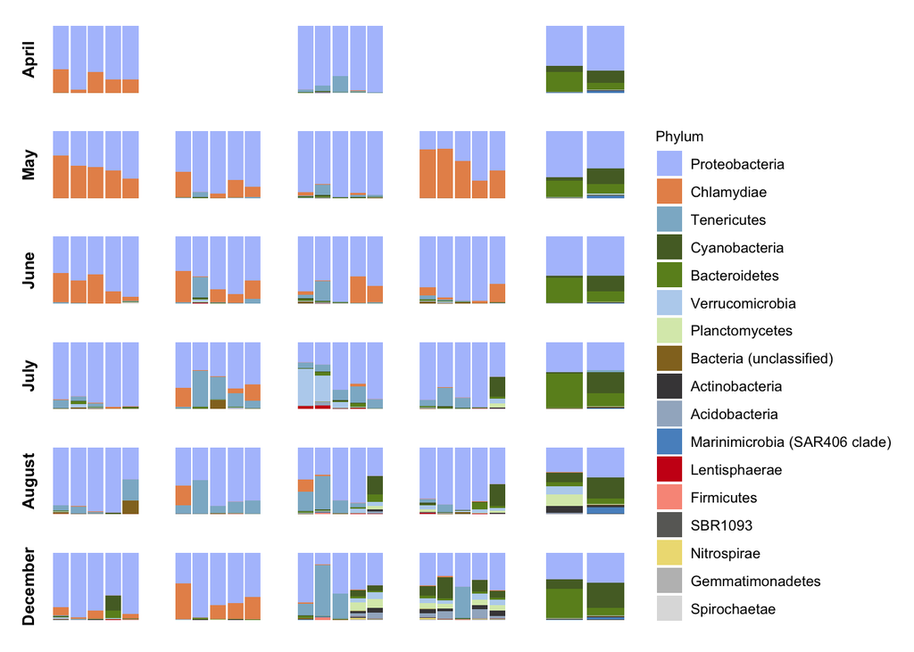

```r
p1_sw_august <- ggplot(sw_august,aes(x = Sample,
                                     y=Abundance,
                                     fill=Phylum)) +
  geom_bar(stat="identity",
           show.legend = FALSE) +
  theme_cowplot() +
  theme(axis.title = element_blank(),
        axis.ticks = element_blank(),
        axis.text = element_blank(),
        axis.line = element_line(color="white")) +
  scale_fill_manual(values=c(Colors_gene_phylum_surface,
                             "lightgoldenrod","grey","grey87")) +
  guides(fill=guide_legend(ncol=1))

p1_sw_december <- ggplot(sw_december,aes(x=Sample,
                                         y=Abundance,
                                         fill=Phylum)) +
  geom_bar(stat="identity",
           show.legend = FALSE) +
  theme_cowplot() +
  theme(axis.title = element_blank(),
        axis.ticks = element_blank(),
        axis.text = element_blank(),
        axis.line = element_line(color="white")) +
  scale_fill_manual(values=c(Colors_gene_phylum_surface,
                             "lightgoldenrod","grey","grey87")) +
  guides(fill=guide_legend(ncol=1))

(p1_april|p1_april2|p2_april|p2_april2|p1_sw_april)/(p1_may|p2_may|p3_may|p4_may|p1_sw_may)/(p1_june|p2_june|p3_june|p4_june|p1_sw_june)/(p1_july|p2_july|p3_july|p4_july|p1_sw_july)/(p1_august|p2_august|p3_august|p4_august|p1_sw_august)/(p1_dec|p2_dec|p3_dec|p4_dec|p1_sw_december)
```

## Endozoicomonas specific analysis

```r
data <- read.table("data/Endozoicomonas_only.txt",
                   header = T,
                   row.names = 1,
                   sep = "\t")
data_t <- t(data)
head(data_t)
```

```
##       zOTU1 zOTU2 zOTU7 zOTU9 zOTU10 zOTU11 zOTU12 zOTU13 zOTU14 zOTU15 zOTU16
## OB1_4  2288  2024    72    73    501    456    388    485    201    139     90
## OB2_4 10199  6820   668   244   2095   1419   1488   2172   3937    854    456
## OB3_4  1871  5185    54    81    353   1073   1139   1261    258    491    120
## OB4_4  3751 11132   326   264    621   2632   2413   2880    575   1201    503
## OB5_4  4471  7498   199   183    956   1569   1595   1822    202    733    924
## IB1_4    85    93 25213 21576      4     22     16     19     34    105     30
##       zOTU17 zOTU18 Other (Endozoicomonas) Other (Bacteria)
## OB1_4      0    131                    663             4842
## OB2_4      1    355                   6498             2210
## OB3_4      0    270                   1927             6611
## OB4_4      1    563                   2699             8201
## OB5_4      1    519                   2042             5934
## IB1_4     12     89                   1720            18580
```

```r
rel_abundance <- (data_t/rowSums(data_t))*100
head(rel_abundance)
```

```
##            zOTU1     zOTU2      zOTU7      zOTU9      zOTU10     zOTU11
## OB1_4 18.5218166 16.384684  0.5828544  0.5909496 4.055694973 3.69141099
## OB2_4 25.8752791 17.302618  1.6947433  0.6190380 5.315100467 3.60006089
## OB3_4  9.0412680 25.055572  0.2609452  0.3914178 1.705808447 5.18507780
## OB4_4  9.9332662 29.479371  0.8633017  0.6991155 1.644510354 6.96996981
## OB5_4 15.6066741 26.172857  0.6946384  0.6387880 3.337056688 5.47682212
## IB1_4  0.1257434  0.137578 37.2984408 31.9181041 0.005917335 0.03254534
##           zOTU12     zOTU13     zOTU14   zOTU15     zOTU16      zOTU17
## OB1_4 3.14093742 3.92617178 1.62713511 1.125233 0.72856796 0.000000000
## OB2_4 3.77511670 5.51045261 9.98832961 2.166633 1.15689060 0.002537041
## OB3_4 5.50401082 6.09355369 1.24673818 2.372668 0.57987823 0.000000000
## OB4_4 6.39002171 7.62671469 1.52269477 3.180446 1.33202691 0.002648165
## OB5_4 5.56757889 6.35995532 0.70511030 2.558643 3.22535605 0.003490645
## IB1_4 0.02366934 0.02810734 0.05029735 0.155330 0.04438001 0.017752004
##          zOTU18 Other (Endozoicomonas) Other (Bacteria)
## OB1_4 1.0604711               5.367117         39.19696
## OB2_4 0.9006495              16.485691          5.60686
## OB3_4 1.3047260               9.311878         31.94646
## OB4_4 1.4909168               7.147397         21.71760
## OB5_4 1.8116448               7.127897         20.71349
## IB1_4 0.1316607               2.544454         27.48602
```

```r
rel_abundance <- t(rel_abundance)

df_cob_april <- melt(t(rel_abundance[,1:5]))
df_cib_april <- melt(t(rel_abundance[,6:10]))

df_cob_may <- melt(t(rel_abundance[,11:15]))
df_i2o_may <- melt(t(rel_abundance[,16:20]))
df_cib_may <- melt(t(rel_abundance[,21:25]))
df_o2i_may <- melt(t(rel_abundance[,26:30]))

df_cob_june <- melt(t(rel_abundance[,31:35]))
df_i2o_june <- melt(t(rel_abundance[,36:40]))
df_cib_june <- melt(t(rel_abundance[,41:45]))
df_o2i_june <- melt(t(rel_abundance[,46:50]))
df_cob_july <- melt(t(rel_abundance[,51:55]))
df_i2o_july <- melt(t(rel_abundance[,56:60]))
df_cib_july <- melt(t(rel_abundance[,61:65]))
df_o2i_july <- melt(t(rel_abundance[,66:70]))
df_cob_august <- melt(t(rel_abundance[,71:75]))
df_i2o_august <- melt(t(rel_abundance[,76:80]))
df_cib_august <- melt(t(rel_abundance[,81:85]))
df_o2i_august <- melt(t(rel_abundance[,86:90]))
df_cob_dec <- melt(t(rel_abundance[,91:95]))
df_i2o_dec <- melt(t(rel_abundance[,96:100]))
df_cib_dec <- melt(t(rel_abundance[,101:105]))
df_o2i_dec <- melt(t(rel_abundance[,106:110]))

sw_april <- melt(t(rel_abundance[,111:112]))
sw_may <- melt(t(rel_abundance[,113:114]))
sw_june <- melt(t(rel_abundance[,115:116]))
sw_july <- melt(t(rel_abundance[,117:118]))
sw_august <- melt(t(rel_abundance[,119:120]))
sw_december <- melt(t(rel_abundance[,121:122]))


colnames(df_cob_april) <- c("Sample", "zOTU", "Abundance")
colnames(df_cib_april) <- c("Sample", "zOTU", "Abundance")
colnames(df_cob_may) <- c("Sample", "zOTU", "Abundance")
colnames(df_cib_may) <- c("Sample", "zOTU", "Abundance")
colnames(df_i2o_may) <- c("Sample", "zOTU", "Abundance")
colnames(df_o2i_may) <- c("Sample", "zOTU", "Abundance")

colnames(df_cob_june) <- c("Sample", "zOTU", "Abundance")
colnames(df_cib_june) <- c("Sample", "zOTU", "Abundance")
colnames(df_i2o_june) <- c("Sample", "zOTU", "Abundance")
colnames(df_o2i_june) <- c("Sample", "zOTU", "Abundance")

colnames(df_cob_july) <- c("Sample", "zOTU", "Abundance")
colnames(df_cib_july) <- c("Sample", "zOTU", "Abundance")
colnames(df_i2o_july) <- c("Sample", "zOTU", "Abundance")
colnames(df_o2i_july) <- c("Sample", "zOTU", "Abundance")

colnames(df_cob_august) <- c("Sample", "zOTU", "Abundance")
colnames(df_cib_august) <- c("Sample", "zOTU", "Abundance")
colnames(df_i2o_august) <- c("Sample", "zOTU", "Abundance")
colnames(df_o2i_august) <- c("Sample", "zOTU", "Abundance")

colnames(df_cob_dec) <- c("Sample", "zOTU", "Abundance")
colnames(df_cib_dec) <- c("Sample", "zOTU", "Abundance")
colnames(df_i2o_dec) <- c("Sample", "zOTU", "Abundance")
colnames(df_o2i_dec) <- c("Sample", "zOTU", "Abundance")

colnames(sw_april)  <- c("Sample", "zOTU", "Abundance")
colnames(sw_may)  <- c("Sample", "zOTU", "Abundance")
colnames(sw_june) <- c("Sample", "zOTU", "Abundance")
colnames(sw_july) <- c("Sample", "zOTU", "Abundance")
colnames(sw_august) <- c("Sample", "zOTU", "Abundance")
colnames(sw_december) <- c("Sample", "zOTU", "Abundance")

test_col <- brewer.pal(12,"Paired")


p1_april <- ggplot(df_cob_april,aes(x = Sample,
                                    y = Abundance,
                                    fill = zOTU)) +
  geom_bar(stat = "identity", show.legend = FALSE) +
  theme_cowplot() +
  theme(axis.title.x = element_blank(),
        axis.title.y = element_text(size = 9,face = "bold"),
        axis.ticks = element_blank(),
        axis.text = element_blank(),
        axis.line = element_line(color = "white")) +
  scale_fill_manual(values = c(test_col,
                               "lightgoldenrod","grey","grey87")) +
  guides(fill = guide_legend(ncol = 1)) +
  labs(y = "April")

p1_april2 <- ggplot(df_cob_april,aes(x = Sample,
                                     y = Abundance,
                                     fill = "white")) +
  geom_bar(stat = "identity", show.legend = FALSE,fill = "white") +
  theme_cowplot() +
  theme(axis.title = element_blank(),
        axis.ticks = element_blank(),
        axis.text = element_blank(),
        axis.line = element_line(color = "white")) +
  guides(fill = guide_legend(ncol = 1))



p2_april <- ggplot(df_cib_april,aes(x = Sample,
                                    y = Abundance,
                                    fill = zOTU)) +
  geom_bar(stat = "identity",
           show.legend = FALSE) +
  theme_cowplot() +
  theme(axis.title = element_blank(),
        axis.ticks = element_blank(),
        axis.text = element_blank(),
        axis.line = element_line(color = "white")) +
  scale_fill_manual(values = c(test_col,
                               "lightgoldenrod","grey","grey87")) +
  guides(fill = guide_legend(ncol = 1))

p2_april2 <- ggplot(df_cib_april,aes(x = Sample,
                                     y = Abundance,
                                     fill = zOTU)) +
  geom_bar(stat = "identity",
           show.legend = FALSE,
           fill = "white") +
  theme_cowplot() +
  theme(axis.title = element_blank(),
        axis.ticks = element_blank(),
        axis.text = element_blank(),
        axis.line = element_line(color = "white")) +
  guides(fill = guide_legend(ncol = 1))


p1_may <- ggplot(df_cob_may,aes(x = Sample,
                                y = Abundance,
                                fill = zOTU)) +
  geom_bar(stat = "identity",
           show.legend = FALSE) +
  theme_cowplot() +
  theme(axis.title.x = element_blank(),
        axis.title.y = element_text(size = 9,face = "bold"),
        axis.ticks = element_blank(),
        axis.text = element_blank(),
        axis.line = element_line(color = "white")) +
  scale_fill_manual(values = c(test_col,
                               "lightgoldenrod","grey","grey87")) +
  guides(fill = guide_legend(ncol = 1)) +
  labs(y = "May")

p2_may <- ggplot(df_i2o_may,aes(x = Sample,
                                y = Abundance,
                                fill = zOTU)) +
  geom_bar(stat = "identity",
           show.legend = FALSE) +
  theme_cowplot() +
  theme(axis.title = element_blank(),
        axis.ticks = element_blank(),
        axis.text = element_blank(),
        axis.line = element_line(color = "white")) +
  scale_fill_manual(values = c(test_col,
                               "lightgoldenrod","grey","grey87")) +
  guides(fill = guide_legend(ncol = 1))
```

```r
p3_may <- ggplot(df_cib_may,aes(x = Sample,
                                y = Abundance,
                                fill = zOTU)) +
  geom_bar(stat = "identity",
           show.legend = FALSE) +
  theme_cowplot() +
  theme(axis.title = element_blank(),
        axis.ticks = element_blank(),
        axis.text = element_blank(),
        axis.line = element_line(color = "white")) +
  scale_fill_manual(values = c(test_col,
                               "lightgoldenrod","grey","grey87")) +
  guides(fill = guide_legend(ncol = 1))

p4_may <- ggplot(df_o2i_may,aes(x = Sample,
                                y = Abundance,
                                fill = zOTU)) +
  geom_bar(stat = "identity",
           show.legend = FALSE) +
  theme_cowplot() +
  theme(axis.title = element_blank(),
        axis.ticks = element_blank(),
        axis.text = element_blank(),
        axis.line = element_line(color = "white")) +
  scale_fill_manual(values = c(test_col,
                               "lightgoldenrod","grey","grey87")) +
  guides(fill = guide_legend(ncol = 1))

p1_june <- ggplot(df_cob_june,aes(x = Sample,
                                  y = Abundance,
                                  fill = zOTU)) +
  geom_bar(stat = "identity",
           show.legend = FALSE) +
  theme_cowplot() +
  theme(axis.title.x = element_blank(),
        axis.title.y = element_text(size = 9,face = "bold"),
        axis.ticks = element_blank(),
        axis.text = element_blank(),
        axis.line = element_line(color = "white")) +
  scale_fill_manual(values = c(test_col,
                               "lightgoldenrod","grey","grey87")) +
  guides(fill = guide_legend(ncol = 1)) +
  labs(y = "June")

p2_june <- ggplot(df_i2o_june,aes(x = Sample,
                                  y = Abundance,
                                  fill = zOTU)) +
  geom_bar(stat = "identity", show.legend = FALSE) +
  theme_cowplot() +
  theme(axis.title = element_blank(),
        axis.ticks = element_blank(),
        axis.text = element_blank(),
        axis.line = element_line(color = "white")) +
  scale_fill_manual(values = c(test_col,
                               "lightgoldenrod","grey","grey87")) +
  guides(fill = guide_legend(ncol = 1))

p3_june <- ggplot(df_cib_june,aes(x = Sample,
                                  y = Abundance,
                                  fill = zOTU)) +
  geom_bar(stat = "identity", show.legend = FALSE) +
  theme_cowplot() +
  theme(axis.title = element_blank(),
        axis.ticks = element_blank(),
        axis.text = element_blank(),
        axis.line = element_line(color = "white")) +
  scale_fill_manual(values = c(test_col,
                               "lightgoldenrod","grey","grey87")) +
  guides(fill = guide_legend(ncol = 1))

p4_june <- ggplot(df_o2i_june,aes(x = Sample,
                                  y = Abundance,
                                  fill = zOTU)) +
  geom_bar(stat = "identity", show.legend = FALSE) +
  theme_cowplot() +
  theme(axis.title = element_blank(),
        axis.ticks = element_blank(),
        axis.text = element_blank(),
        axis.line = element_line(color = "white")) +
  scale_fill_manual(values = c(test_col,
                               "lightgoldenrod","grey","grey87")) +
  guides(fill = guide_legend(ncol = 1))

p1_july <- ggplot(df_cob_july,aes(x = Sample,
                                  y = Abundance,
                                  fill = zOTU)) +
  geom_bar(stat = "identity",
           show.legend  = FALSE) +
  theme_cowplot() +
  theme(axis.title.x = element_blank(),
        axis.title.y = element_text(size = 9,
                                    face = "bold"),
        axis.ticks = element_blank(),
        axis.text = element_blank(),
        axis.line = element_line(color = "white")) +
  scale_fill_manual(values = c(test_col,
                               "lightgoldenrod","grey","grey87")) +
  guides(fill = guide_legend(ncol = 1)) +
  labs(y = "July")

p2_july <- ggplot(df_i2o_july,aes(x = Sample,
                                  y = Abundance,
                                  fill = zOTU)) +
  geom_bar(stat = "identity", show.legend = FALSE) +
  theme_cowplot() +
  theme(axis.title = element_blank(),
        axis.ticks = element_blank(),
        axis.text = element_blank(),
        axis.line = element_line(color = "white")) +
  scale_fill_manual(values = c(test_col,
                               "lightgoldenrod","grey","grey87")) +
  guides(fill = guide_legend(ncol = 1))

p3_july <- ggplot(df_cib_july,aes(x = Sample,
                                  y = Abundance,
                                  fill = zOTU)) +
  geom_bar(stat = "identity", show.legend = FALSE) +
  theme_cowplot() +
  theme(axis.title = element_blank(),
        axis.ticks = element_blank(),
        axis.text = element_blank(),
        axis.line = element_line(color = "white")) +
  scale_fill_manual(values = c(test_col,
                               "lightgoldenrod","grey","grey87")) +
  guides(fill = guide_legend(ncol = 1))

p4_july <- ggplot(df_o2i_july,aes(x = Sample,
                                  y = Abundance,
                                  fill = zOTU)) +
  geom_bar(stat = "identity", show.legend = FALSE) +
  theme_cowplot() +
  theme(axis.title = element_blank(),
        axis.ticks = element_blank(),
        axis.text = element_blank(),
        axis.line = element_line(color = "white")) +
  scale_fill_manual(values = c(test_col,
                               "lightgoldenrod","grey","grey87")) +
  guides(fill = guide_legend(ncol = 1))

p1_august <- ggplot(df_cob_august,aes(x = Sample,
                                      y = Abundance,
                                      fill = zOTU)) +
  geom_bar(stat = "identity",
           show.legend = FALSE) +
  theme_cowplot() +
  theme(axis.title.x = element_blank(),
        axis.title.y = element_text(size = 9,
                                    face = "bold"),
        axis.ticks  = element_blank(),
        axis.text = element_blank(),
        axis.line  = element_line(color = "white")) +
  scale_fill_manual(values = c(test_col,
                               "lightgoldenrod","grey","grey87")) +
  guides(fill = guide_legend(ncol = 1)) +
  labs(y = "August")
```

```r
p2_august <- ggplot(df_i2o_august,aes(x = Sample,
                                      y = Abundance,
                                      fill = zOTU)) +
  geom_bar(stat = "identity", show.legend = FALSE) +
  theme_cowplot() +
  theme(axis.title = element_blank(),
        axis.ticks = element_blank(),
        axis.text = element_blank(),
        axis.line = element_line(color = "white")) +
  scale_fill_manual(values = c(test_col,
                               "lightgoldenrod","grey","grey87")) +
  guides(fill = guide_legend(ncol = 1))

p3_august <- ggplot(df_cib_august,aes(x = Sample,
                                      y = Abundance,
                                      fill = zOTU)) +
  geom_bar(stat = "identity", show.legend = FALSE) +
  theme_cowplot() +
  theme(axis.title = element_blank(),
        axis.ticks = element_blank(),
        axis.text = element_blank(),
        axis.line = element_line(color = "white")) +
  scale_fill_manual(values = c(test_col,
                               "lightgoldenrod","grey","grey87")) +
  guides(fill = guide_legend(ncol = 1))

p4_august <- ggplot(df_o2i_august,aes(x = Sample,
                                      y = Abundance,
                                      fill = zOTU)) +
  geom_bar(stat = "identity", show.legend = FALSE) +
  theme_cowplot() +
  theme(axis.title = element_blank(),
        axis.ticks = element_blank(),
        axis.text = element_blank(),
        axis.line = element_line(color = "white")) +
  scale_fill_manual(values = c(test_col,
                               "lightgoldenrod","grey","grey87")) +
  guides(fill = guide_legend(ncol = 1))


p1_dec <- ggplot(df_cob_dec,aes(x = Sample,
                                y = Abundance,
                                fill = zOTU)) +
  geom_bar(stat = "identity",
           show.legend = FALSE) +
  theme_cowplot() +
  theme(axis.title.x  = element_blank(),
        axis.title.y = element_text(size = 9,
                                    face = "bold"),
        axis.ticks = element_blank(),
        axis.text = element_blank(),
        axis.line = element_line(color = "white")) +
  scale_fill_manual(values = c(test_col,
                               "lightgoldenrod","grey","grey87")) +
  guides(fill = guide_legend(ncol = 1)) +
  labs(y = "December")


p2_dec <- ggplot(df_i2o_dec,aes(x = Sample,
                                y = Abundance,
                                fill = zOTU)) +
  geom_bar(stat = "identity", show.legend = FALSE) +
  theme_cowplot() +
  theme(axis.title = element_blank(),
        axis.ticks = element_blank(),
        axis.text = element_blank(),
        axis.line = element_line(color = "white")) +
  scale_fill_manual(values = c(test_col,
                               "lightgoldenrod","grey","grey87")) +
  guides(fill = guide_legend(ncol = 1))

p3_dec <- ggplot(df_cib_dec,aes(x = Sample,
                                y = Abundance,
                                fill = zOTU)) +
  geom_bar(stat = "identity", show.legend = FALSE) +
  theme_cowplot() +
  theme(axis.title = element_blank(),
        axis.ticks = element_blank(),
        axis.text = element_blank(),
        axis.line = element_line(color = "white")) +
  scale_fill_manual(values = c(test_col,
                               "lightgoldenrod","grey","grey87")) +
  guides(fill = guide_legend(ncol = 1))

p4_dec <- ggplot(df_o2i_dec,aes(x = Sample,
                                y = Abundance,
                                fill = zOTU)) +
  geom_bar(stat = "identity", show.legend = FALSE) +
  theme_cowplot() +
  theme(axis.title = element_blank(),
        axis.ticks = element_blank(),
        axis.text = element_blank(),
        axis.line = element_line(color = "white")) +
  scale_fill_manual(values = c(test_col,
                               "lightgoldenrod","grey","grey87")) +
  guides(fill = guide_legend(ncol = 1))

p1_sw_april <- ggplot(sw_april,aes(x = Sample,
                                   y = Abundance,
                                   fill = zOTU)) +
  geom_bar(stat = "identity", show.legend = FALSE) +
  theme_cowplot() +
  theme(axis.title = element_blank(),
        axis.ticks = element_blank(),
        axis.text = element_blank(),
        axis.line = element_line(color = "white")) +
  scale_fill_manual(values = c(test_col,
                               "lightgoldenrod","grey","grey87")) +
  guides(fill = guide_legend(ncol = 1))

p1_sw_may <- ggplot(sw_may,aes(x = Sample,
                               y = Abundance,
                               fill = zOTU)) +
  geom_bar(stat = "identity",
           show.legend  = FALSE) +
  theme_cowplot() +
  theme(axis.title = element_blank(),
        axis.ticks = element_blank(),
        axis.text = element_blank(),
        axis.line = element_line(color = "white")) +
  scale_fill_manual(values = c(test_col,
                               "lightgoldenrod","grey","grey87")) +
  guides(fill = guide_legend(ncol = 1))

p1_sw_june <- ggplot(sw_june,aes(x = Sample,
                                 y = Abundance,
                                 fill = zOTU)) +
  geom_bar(stat = "identity",
           show.legend = FALSE) +
  theme_cowplot() +
  theme(axis.title  = element_blank(),
        axis.ticks =  element_blank(),
        axis.text = element_blank(),
        axis.line = element_line(color = "white")) +
  scale_fill_manual(values = c(test_col,
                               "lightgoldenrod","grey","grey87")) +
  guides(fill = guide_legend(ncol = 1))

p1_sw_july <- ggplot(sw_july,aes(x = Sample,
                                 y = Abundance,
                                 fill = zOTU)) +
  geom_bar(stat = "identity",
           show.legend  = TRUE) +
  theme_cowplot() +
  theme(legend.title = element_text(size = 8),
        legend.text = element_text(size = 8),
        axis.title  = element_blank(),
        axis.ticks  = element_blank(),
        axis.text =  element_blank(),
        axis.line =  element_line(color = "white")) +
  scale_fill_manual(values = c(test_col,
                               "lightgoldenrod","grey","grey87")) +
  guides(fill = guide_legend(ncol = 1))
```

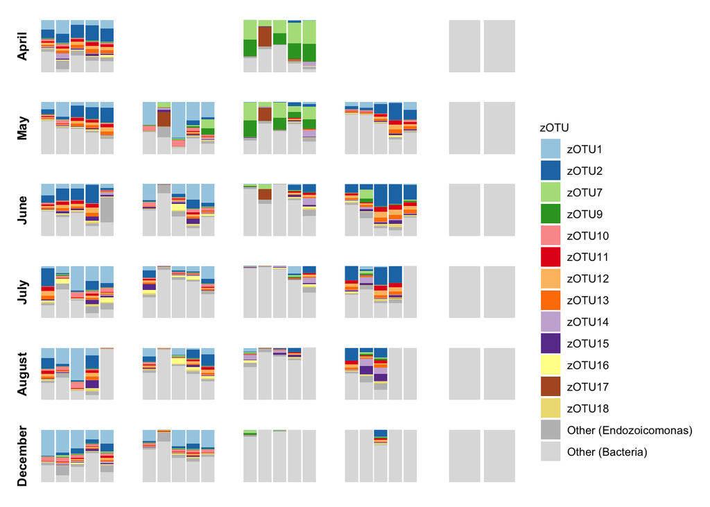

```r
p1_sw_august <- ggplot(sw_august,aes(x = Sample,
                                     y = Abundance,
                                     fill = zOTU)) +
  geom_bar(stat = "identity",
           show.legend = FALSE) +
  theme_cowplot() +
  theme(axis.title = element_blank(),
        axis.ticks  = element_blank(),
        axis.text = element_blank(),
        axis.line = element_line(color = "white")) +
  scale_fill_manual(values = c(test_col,
                               "lightgoldenrod","grey","grey87")) +
  guides(fill = guide_legend(ncol = 1))

p1_sw_december <- ggplot(sw_december,aes(x = Sample,
                                         y = Abundance,
                                         fill = zOTU)) +
  geom_bar(stat = "identity",
           show.legend = FALSE) +
  theme_cowplot() +
  theme(axis.title = element_blank(),
        axis.ticks = element_blank(),
        axis.text = element_blank(),
        axis.line =  element_line(color = "white")) +
  scale_fill_manual(values = c(test_col,
                               "lightgoldenrod","grey","grey87")) +
  guides(fill = guide_legend(ncol = 1))

(p1_april|p1_april2|p2_april|p2_april2|p1_sw_april)/(p1_may|p2_may|p3_may|p4_may|p1_sw_may)/(p1_june|p2_june|p3_june|p4_june|p1_sw_june)/(p1_july|p2_july|p3_july|p4_july|p1_sw_july)/(p1_august|p2_august|p3_august|p4_august|p1_sw_august)/(p1_dec|p2_dec|p3_dec|p4_dec|p1_sw_december)
```